# Stat 437 HW2

true

# Problem 1

Please refer to the NYC flight data `nycflights13` that has been discussed in the lecture notes and whose manual can be found at https://cran.r-project.org/web/packages/nycflights13/index.html. We will use `flights`, a tibble from `nycflights13`. You are interested in looking into the average `arr_delay` for 4 different `month` 12, 1, 7 and 8, for 3 different `carrier` “UA”, “AA” and “DL”, and for `distance` that are greater than 700 miles, since you suspect that colder months and longer distances may result in longer average arrival delays. Note that you need to extract observations from `flights`, and that you are required to use `dplyr` for this purpose. The following tasks and questions are based on the extracted observations.

#### (1.a)

For each combination of the values of `carrier` and `month`, obtain the average `arr_delay` and obtain the average `distance`. Plot the average `arr_delay` against the average `distance`, use `carrier` as facet; add a title “Base plot” and center the title in the plot. This will be your base plot, say, as object `p`. Show the plot `p`.

```r
library(nycflights13)
library(dplyr)
```

```r
library(ggplot2)

# Filtering data
filtered_flights <- flights %>%
  filter(month %in% c(12, 1, 7, 8),
         carrier %in% c("UA", "AA", "DL"),
         distance > 700) %>%
  group_by(carrier, month) %>%
  summarise(avg_arr_delay = mean(arr_delay, na.rm = TRUE),
            avg_distance = mean(distance, na.rm = TRUE))
print(filtered_flights)
```

```
## # A tibble: 12 × 4
## # Groups:   carrier [3]
##    carrier month avg_arr_delay avg_distance
##    <chr>   <int>         <dbl>        <dbl>
##  1 AA          1          1.19        1404.
##  2 AA          7          4.28        1376.
##  3 AA          8         -2.51        1378.
##  4 AA         12          7.52        1412.
##  5 DL          1         -4.04        1314.
##  6 DL          7         15.3         1357.
##  7 DL          8          1.31        1352.
##  8 DL         12          6.22        1324.
##  9 UA          1          3.72        1598.
## 10 UA          7         10.2         1708.
## 11 UA          8          3.63        1722.
## 12 UA         12         14.0         1655.
```

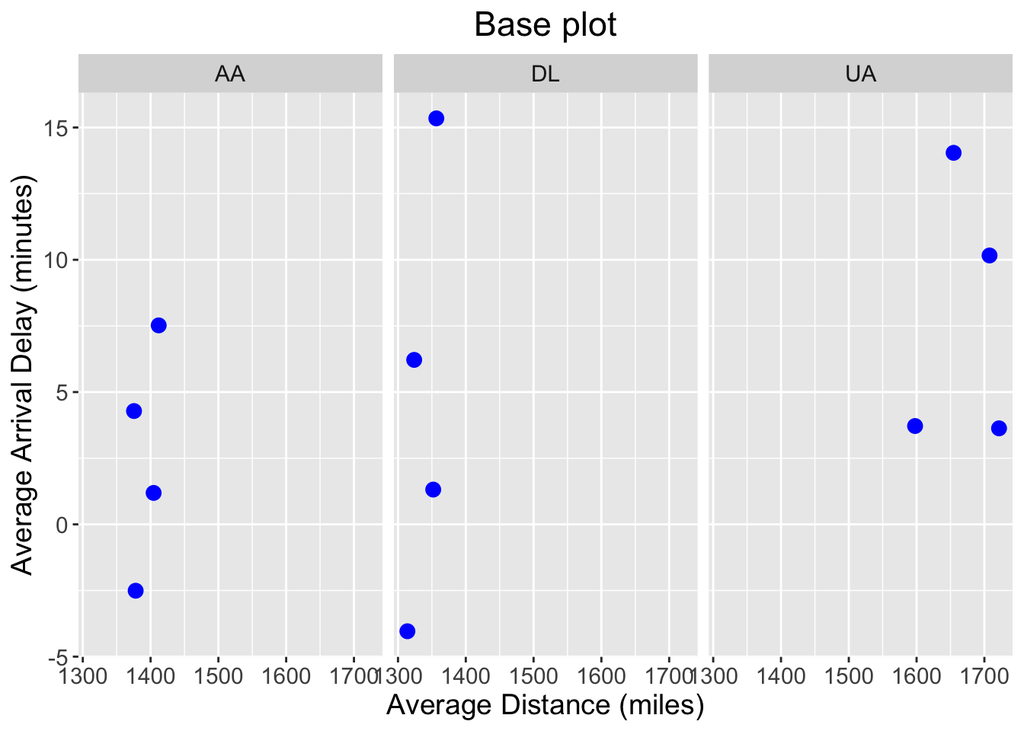

```r
p <- ggplot(filtered_flights, aes(x = avg_distance, y = avg_arr_delay)) +
  geom_point(color = "blue", size = 3) +
  facet_wrap(~ carrier) +
  labs(title = "Base plot", x = "Average Distance (miles)", y = "Average Arrival Delay (minutes)") +
  theme(plot.title = element_text(hjust = 0.5),
        text = element_text(size = 14))

print(p)
```

#### (1.b)

Modify `p` as follows to get a plot `p1`: connect the points for each `carrier` via one type of dashed line; code the 3 levels of `carrier` as $\alpha_1$, $\beta_{1,2}$ and $\gamma^{[0]}$, and display them in the strip texts; change the legend title into “My $\zeta$” (this legend is induced when you connect points for each `carrier` by a type of line), and put the legend in horizontal direction at the bottom of the plot; add a title “With math expressions” and center the title in the plot. Show the plot `p1`.

```r
filtered_flights <- flights %>%
  filter(month %in% c(12, 1, 7, 8),
         carrier %in% c("UA", "AA", "DL"),
         distance > 700) %>%
  group_by(carrier, month) %>%
  summarise(avg_arr_delay = mean(arr_delay, na.rm = TRUE),
            avg_distance = mean(distance, na.rm = TRUE))
```

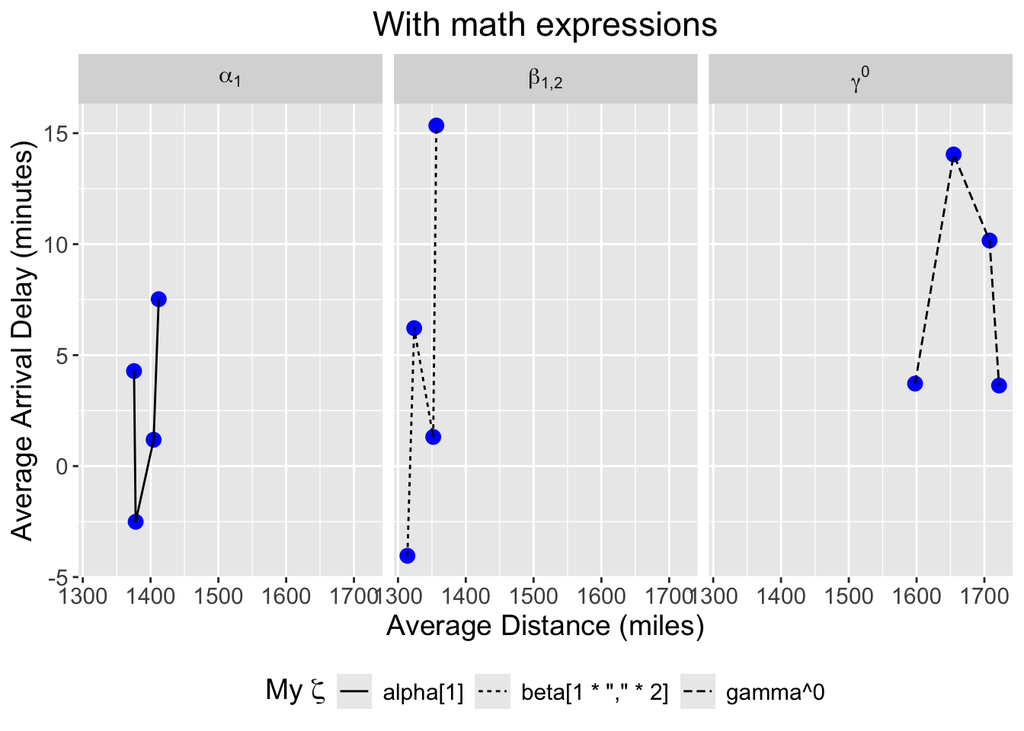

```r
filtered_flights$carrier <- factor(filtered_flights$carrier,
                                   levels = c("AA", "DL", "UA"),
                                   labels = c(expression(alpha[1]),
                                              expression(beta[1 * "," * 2]),
                                              expression(gamma^0)))

p1 <- ggplot(filtered_flights, aes(x = avg_distance, y = avg_arr_delay, group = carrier, linetype = carrier)) +
  geom_point(color = "blue", size = 3) +
  geom_line() +
  facet_wrap(~ carrier, labeller = label_parsed) +
  labs(title = "With math expressions",
       x = "Average Distance (miles)",
       y = "Average Arrival Delay (minutes)",
       linetype = expression("My " * zeta)) +
  theme(plot.title = element_text(hjust = 0.5),
        legend.position = "bottom",
        legend.direction = "horizontal",
        text = element_text(size = 14))

print(p1)
```

#### (1.c)

Modify `p1` as follows to get a plot `p2`: set the font size of strip text to be 12 and rotate the strip texts counterclockwise by 15 degrees; set the font size of the x-axis text to be 10 and rotate the x-axis text clockwise by 30 degrees; set the x-axis label as “$\hat{\mu}$ for mean arrival delay”; add a title “With front and text adjustments” and center the title in the plot. Show the plot `p2`

```r
filtered_flights <- flights %>%
  filter(month %in% c(12, 1, 7, 8),
         carrier %in% c("UA", "AA", "DL"),
         distance > 700) %>%
  group_by(carrier, month) %>%
  summarise(avg_arr_delay = mean(arr_delay, na.rm = TRUE),
            avg_distance = mean(distance, na.rm = TRUE))
```

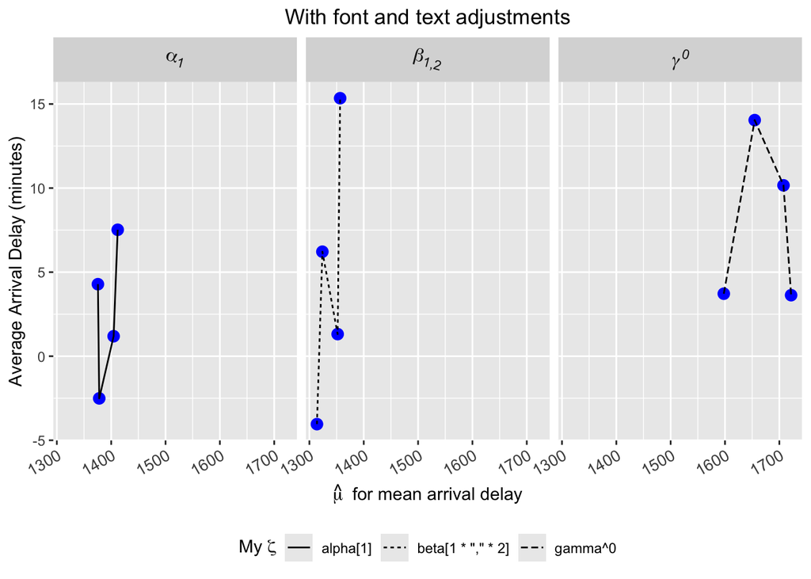

```r
filtered_flights$carrier <- factor(filtered_flights$carrier,
                                   levels = c("AA", "DL", "UA"),
                                   labels = c(expression(alpha[1]),
                                              expression(beta[1 * "," * 2]),
                                              expression(gamma^0)))

p2 <- ggplot(filtered_flights, aes(x = avg_distance, y = avg_arr_delay, group = carrier, linetype = carrier)) +
  geom_point(color = "blue", size = 3) +
  geom_line() +
  facet_wrap(~ carrier, labeller = label_parsed) +
  labs(title = "With font and text adjustments",
       x = expression(hat(mu) ~ " for mean arrival delay"),
       y = "Average Arrival Delay (minutes)",
       linetype = expression("My " * zeta)) +
  theme(plot.title = element_text(hjust = 0.5),
        legend.position = "bottom",
        legend.direction = "horizontal",
        strip.text = element_text(size = 12, angle = -15),
        axis.text.x = element_text(size = 10, angle = 30, hjust = 1))

print(p2)
```

#### Interpretation:

# Problem 2

This problem requires you to visualize the binary relationship between members of a karate club as an undirected graph. Please install the R library `igraphdata`, from which you can obtain the data set `karate` and work on it. Create a graph for `karate`. Once you obtain the graph, you will see that each vertex is annotated by a number or letter. What do the numbers or letters refer to? Do you see subgraphs of the graph? If so, what do these subgraphs mean?

```r
library(igraph)
library(igraphdata)

data("karate")
print(karate)
```

```
## This graph was created by an old(er) igraph version.
## ℹ Call `igraph::upgrade_graph()` on it to use with the current igraph version.
## For now we convert it on the fly...
```

```
## IGRAPH 4b458a1 UNW- 34 78 -- Zachary's karate club network
## + attr: name (g/c), Citation (g/c), Author (g/c), Faction (v/n), name
## | (v/c), label (v/c), color (v/n), weight (e/n)
## + edges from 4b458a1 (vertex names):
##  [1] Mr Hi  --Actor 2  Mr Hi  --Actor 3  Mr Hi  --Actor 4  Mr Hi  --Actor 5
##  [5] Mr Hi  --Actor 6  Mr Hi  --Actor 7  Mr Hi  --Actor 8  Mr Hi  --Actor 9
##  [9] Mr Hi  --Actor 11 Mr Hi  --Actor 12 Mr Hi  --Actor 13 Mr Hi  --Actor 14
## [13] Mr Hi  --Actor 18 Mr Hi  --Actor 20 Mr Hi  --Actor 22 Mr Hi  --Actor 32
## [17] Actor 2--Actor 3  Actor 2--Actor 4  Actor 2--Actor 8  Actor 2--Actor 14
## [21] Actor 2--Actor 18 Actor 2--Actor 20 Actor 2--Actor 22 Actor 2--Actor 31
## [25] Actor 3--Actor 4  Actor 3--Actor 8  Actor 3--Actor 9  Actor 3--Actor 10
## + ... omitted several edges
```

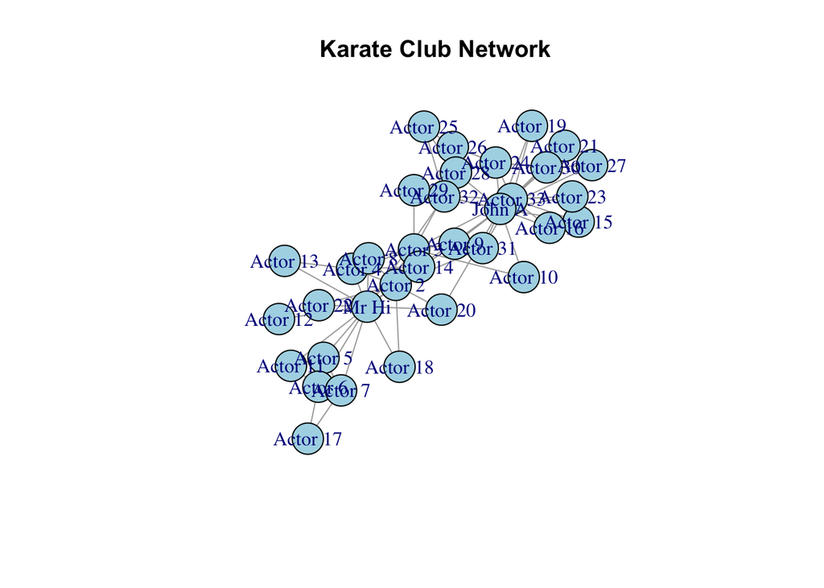

```r
plot(karate, vertex.size = 20, vertex.label = V(karate)$name,
     main = "Karate Club Network", vertex.color ="lightblue")
```

#### Interpretation:

The numbers or labels on the nodes in the Karate Club Network represent individual members of the club, with each connection showing a social interaction between them. Some key members, like “Mr. Hi”, stand out as more central, meaning they had stronger influence or more connections in the group. Looking at the graph, we can clearly see two distinct clusters, which represent the split that happened in the club. This divide was caused by a conflict between the club’s instructor (Mr. Hi) and the administrator, leading members to take sides. These subgroups are a great example of how social networks naturally form based on relationships and influence.

# Problem 3

This problem requires to to create an interactive plot using `plotly`. If you want to display properly the plot in your HW answers, you may well need to set your HW document as an html file (instead of doc, docx or pdf file) when you compile your R codes.

Please use the `mpg` data set we have discussed in the lectures. Create an interactive, scatter plot between “highway miles per gallon” `hwy` (on the y-axis) and “engine displacement in litres” `displ` (on the x-axis) with the `color` aesthetic designated by “number of cylinders” `cyl`, and set the x-axis label as “engine displacement in litres” and y-axis label as “highway miles per gallon”. You need to check the object type for `cyl` and set it correctly when creating the plot. Add the title “# of cylinders” to the legend and adjust the vertical position of the legend, if you can. For the last, you may look through https://plotly.com/r/legend/ for help.

```r
library(ggplot2)
library(plotly)
p <- ggplot(mpg, aes(x = displ, y = hwy, color = cyl)) +
  geom_point(size = 3, alpha = 0.7) +
  labs(title = "Engine Displacement vs. Highway MPG",
       x = "Engine Displacement (litres)",
       y = "Highway Miles per Gallon",
       color = "# of Cylinders") +
  theme_minimal() +
  theme(legend.title = element_text(size = 12),
        legend.position = "top")

p_interactive <- ggplotly(p)
p_interactive
```

[interactive chart not shown]

#### Interpretation:

This interactive scatter plot shows the relationship between engine displacement (in litres) and highway miles per gallon (MPG) for different vehicles, with color representing the number of cylinders. From the graph, there’s a clear negative correlation—as engine displacement increases, highway MPG tends to decrease. This makes sense because larger engines generally consume more fuel, leading to lower fuel efficiency. Looking at the color gradient, vehicles with fewer cylinders (4 cylinders, darker shades) tend to have higher MPG and smaller engine displacements, while those with more cylinders (6 or 8, lighter shades) typically have larger displacements and lower MPG. This pattern aligns with expectations, as higher-cylinder engines are more powerful but less fuel-efficient. The interactive nature of the plot allows users to hover over points and explore specific vehicles, making it easier to analyze trends and exceptions in fuel efficiency across different engine types.